# Data Analysis About Academic Calandar

2Lazy2BeOriginal

2024-12-24

# Summary

The University of Manitoba’s [academic calendar](https://umanitoba-ca-preview.courseleaf.com) traditionally is used as a guide for students and faculty. The course offerings are formatted with a department prefix (capitalized and generally 4 letters long) with a 4 digit code differentiating the various courses offered. Each course also has a title and a description that highlights the prerequisites, co-requisites and mutually exclusive courses.

This project explores the academic calendar as a dataset, focusing on the organization and relationships embedded within the course codes—four-digit identifiers that reflect the level, type, and sequence of university courses. Using a combination of keyword analysis, structural diagramming, and graph theory, we uncover the latent patterns and organizational logic behind the curriculum.

Our analysis includes:

- A breakdown of how course codes are constructed and what information they encode.
- A lexicon of common academic terms and categories, allowing for natural language analysis of course descriptions and requirements.
- A graph-based model representing relationships between courses (such as prerequisites and co-requisites), programs, and departments.

**Note**: There are many courses that are no longer offered at the University of Manitoba and are still included in this document. The Academic Calendar does not differentiate between which classes are currently still offered or not.

**Note:** The University of Manitoba offers courses in French through the [Université de Saint-Boniface](https://ustboniface.ca). To distinguish these from their English counterparts, the course codes typically end in a **1**. However, the academic calendar includes only a small subset of these courses—in fact, just three French-designated courses (ending in 1) are listed, suggesting that the majority are not featured in the central calendar.

# Course Code analysis

This section explores the rationale behind the assignment of four-digit course codes at the University of Manitoba. Typically, course codes begin with a digit from 1 to 4, representing introductory (1000-level) to advanced undergraduate (4000-level) courses. However, there are exceptions to this structure, such as ENGL 930, which does not follow to the standard numbering convention. ENGL 930 appears to fulfill a specific administrative or curricular function, such as meeting a writing requirement. In this context, it may be helpful to interpret it as ENGL 0930, with an implied leading zero that aligns it with first-year or preparatory-level coursework. This suggests that the four-digit codes are rarely arbitrary chosen—often, the trailing digits are chosen for clarity, simplicity, or pattern recognition.

## Most common codes

First, we examine which course codes are most frequently used across all departments. The following section highlights the top 15 most common codes, accompanied by a diagram that visually presents their distribution in a clear and organized manner.

```
## code
## 4010 3010 1000 2200 2600 2500 2020 3100 4100 2010 3000 4520 2000 2100 2400
##   24   22   20   20   20   19   18   18   18   17   17   17   16   16   16
```

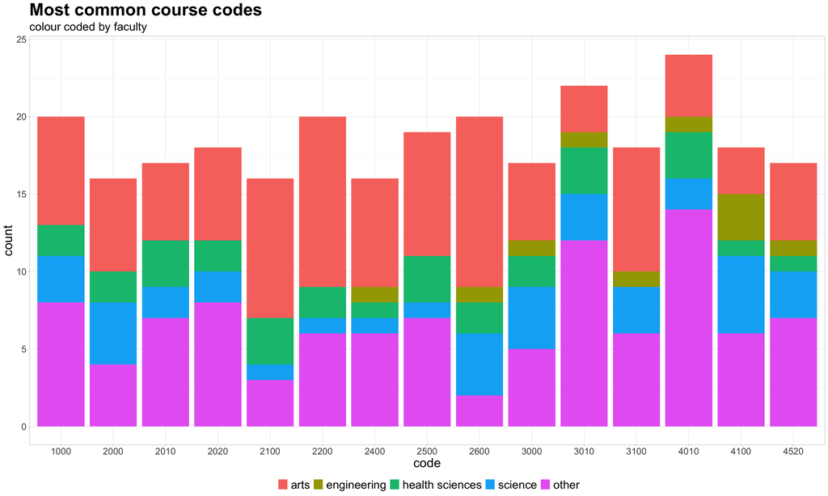

## What courses uses the most frequent codes

Next, let’s examine the titles associated with the top five most frequently selected course codes.

| Departments with course code 4010 with the name of the course Count | Departments with course code 4010 with the name of the course Department | Departments with course code 4010 with the name of the course Faculty | Departments with course code 4010 with the name of the course Course Name |
| --- | --- | --- | --- |
| 1 | AGRI | agriculture | Practising the Profession of Agrology II |
| 2 | FOOD | agriculture | Food Process 2 |
| 3 | EVAR | architecture | Architecture Design Studio 4 |
| 4 | EVIE | architecture | Interior Design Studio 4.1 |
| 5 | EVLU | architecture | Community Design Process and Method: Advanced Placemaking |
| 6 | ECON | arts | Advanced Microeconomic Theory |
| 7 | HIST | arts | Imperialism, Decolonization and Neo-Colonialism, 1700 to the Present (M) |
| 8 | POLS | arts | U.N. Security Council |
| 9 | RLGN | arts | Advanced Topics in Buddhism |
| 10 | ACC | business | Auditing |
| 11 | ACT | business | Regression Modeling in Actuarial Science |
| 12 | ACT | business | Regression Modeling in Actuarial Science |
| 13 | GMGT | business | Strategic Management |
| 14 | LEAD | business | Leading Change |
| 15 | MKT | business | Marketing Analytics |
| 16 | EDUB | education | Pedagogy for Sustainable Well-being: Science, Mathematics and Social Studies |
| 17 | ENG | engineering | Practicing Professional Engineering in Manitoba |
| 18 | ENVR | environment-earth-resources | Field Topics in Environmental Science 2 |
| 19 | BGEN | health sciences | Project Course in Human Genetics |
| 20 | MDFY | health sciences | Advanced Clinical Skills II |
| 21 | PHMD | health sciences | Foundations of Pharmacy Research Methods |
| 22 | MUSC | music | French Diction and Repertoire |
| 23 | DATA | science | Data Science Capstone Project |
| 24 | PHYS | science | General Relativity and Gravitation |

| Departments with course code 3010 with the name of the course Count | Departments with course code 3010 with the name of the course Department | Departments with course code 3010 with the name of the course Faculty | Departments with course code 3010 with the name of the course Course Name |
| --- | --- | --- | --- |
| 1 | FOOD | agriculture | Food Process 1 |
| 2 | EVAR | architecture | Architecture Design Studio 2 |
| 3 | EVIE | architecture | Interior Design Studio 3.2 |
| 4 | EVLU | architecture | Landscape and Urbanism Theory |
| 5 | ECON | arts | Microeconomic Theory 2 |
| 6 | ENGL | arts | Shakespeare |
| 7 | LABR | arts | Labour Law |
| 8 | ACC | business | Data Analytics in Accounting |
| 9 | FIN | business | Fixed Income Securities |
| 10 | GMGT | business | Management Decision-Making |
| 11 | LEAD | business | Negotiation and Conflict Management |
| 12 | IDM | business | Sustainable Business |
| 13 | EDUB | education | Classroom Community and Early Years Literacy |
| 14 | ECE | engineering | Elements of Electric Machines and Digital Systems |
| 15 | ENVR | environment-earth-resources | Field Topics in Environmental Science 1 |
| 16 | BGEN | health sciences | Genetics in Biomedicine |
| 17 | MDFY | health sciences | Advanced Clinical Skills I |
| 18 | PHMD | health sciences | Pharmacy Management |
| 19 | MUSC | music | Advanced Diction 1 |
| 20 | COMP | science | Distributed Computing |
| 21 | DATA | science | Data Science with Real World Data Sets |
| 22 | MBIO | science | Mechanisms of Microbial Disease |

| Departments with course code 1000 with the name of the course Count | Departments with course code 1000 with the name of the course Department | Departments with course code 1000 with the name of the course Faculty | Departments with course code 1000 with the name of the course Course Name |
| --- | --- | --- | --- |
| 1 | ABIZ | agriculture | Introduction to Agribusiness Management |
| 2 | ENTM | agriculture | World of Bugs |
| 3 | FOOD | agriculture | Food Safety Today and Tomorrow |
| 4 | PLNT | agriculture | Urban Agriculture |
| 5 | CDN | arts | Introduction to Canada |
| 6 | HUNG | arts | Introduction to Hungarian 1 |
| 7 | INDG | arts | Orientation Course: The Colonizers and the Colonized |
| 8 | ARA | arts | Elementary Arabic |
| 9 | LING | arts | Introduction to Linguistics 1: Foundations of Language |
| 10 | ASLL | arts | American Sign Language 1 |
| 11 | SOC | arts | Introduction to Sociology |
| 12 | GMGT | business | Writing Skills for Business |
| 13 | SCM | business | Introduction to Project Management |
| 14 | EER | environment-earth-resources | Earth: A User’s Guide |
| 15 | ENVR | environment-earth-resources | Environmental Science 1 - Concepts |
| 16 | FMLY | health sciences | Families in Contemporary Canadian Society |
| 17 | PHMD | health sciences | Introduction to Professional Practice |
| 18 | COMP | science | Introductory Programming: Think Like a Computer |
| 19 | SCI | science | Topics in Science 1 |
| 20 | STAT | science | Basic Statistical Analysis 1 |

| Departments with course code 2200 with the name of the course Count | Departments with course code 2200 with the name of the course Department | Departments with course code 2200 with the name of the course Faculty | Departments with course code 2200 with the name of the course Course Name |
| --- | --- | --- | --- |
| 1 | EVDS | architecture | Ecology and Design |
| 2 | CATH | arts | Catholicism and Human Sexuality |
| 3 | THTR | arts | Canadian Indigenous Theatre |
| 4 | SPAN | arts | Spanish American Culture and Civilization |
| 5 | ITLN | arts | Let’s Get Graphic: Italian through Graphic Novels |
| 6 | UKRN | arts | Ukrainian Myth, Rites and Rituals |
| 7 | HIST | arts | Labour History: Canada and Beyond (C) |
| 8 | ICEL | arts | Intermediate Icelandic 1 |
| 9 | LABR | arts | Labour History: Canada and Beyond (C) |
| 10 | PHIL | arts | Intermediate Logic |
| 11 | RLGN | arts | Atheism |
| 12 | SOC | arts | Sociology Through Film |
| 13 | FIN | business | Corporate Finance |
| 14 | SGMT | business | Global Management |
| 15 | GEOG | environment-earth-resources | Introduction to Thematic Cartography (TS) |
| 16 | NURS | health sciences | Selected Topics in Aging and Health |
| 17 | RESP | health sciences | Primary Care in Respiratory Therapy |
| 18 | KPER | kin-rec | Planning Principles |
| 19 | KIN | kin-rec | Basic Trauma and Life Support |
| 20 | BIOL | science | The Invertebrates |

| Departments with course code 2600 with the name of the course Count | Departments with course code 2600 with the name of the course Department | Departments with course code 2600 with the name of the course Faculty | Departments with course code 2600 with the name of the course Course Name |
| --- | --- | --- | --- |
| 1 | BIOE | agriculture | Plant and Animal Physiology for Engineers |
| 2 | EVDS | architecture | Tectonic Precedent |
| 3 | ANTH | arts | Old World Prehistory |
| 4 | ASIA | arts | Japanese Film |
| 5 | CATH | arts | Pilgrimage and the Localization of Catholic Devotion |
| 6 | ENGL | arts | Writing and Gender |
| 7 | THTR | arts | Special Studies |
| 8 | RUSN | arts | Special Topics in Russian Culture in English Translation |
| 9 | UKRN | arts | Special Topics in Ukrainian Studies |
| 10 | POL | arts | Polish Culture until 1918 |
| 11 | HIST | arts | Introduction to Ukraine (E) |
| 12 | LING | arts | Verbal Art |
| 13 | WOMN | arts | Sex, Gender, Space and Place |
| 14 | BIOE | engineering | Plant and Animal Physiology for Engineers |
| 15 | HEAL | health sciences | Integration of Health Determinants of Individuals |
| 16 | FMLY | health sciences | Foundations of Childhood Developmental Health |
| 17 | BIOL | science | Introduction to Computational Biology |
| 18 | CHEM | science | Physical Chemistry 1 |
| 19 | COMP | science | Technical Communication in Computer Science |
| 20 | PHYS | science | Electromagnetic Field Theory |

This non-intuitive conclusion can be explained by **sampling bias**. While lower-level courses such as 1010 or 1020 may have more sections and larger enrollments, making them more known to students, the dataset reflects the number of unique departments using each code—not the number of students enrolled or sections offered. In other words, 4010 is more widely adopted across departments, even if courses like 1010 are more commonly experienced by students. A helpful analogy is traffic patterns: similar to how you’re more likely to find yourself in rush hour due to the higher volume of cars in a shorter time window, you’re more likely to encounter popular introductory courses—but that doesn’t mean they’re the most broadly used across all academic units.

## What is the most common course number by faculty

Next, we group the data by faculty to examine whether any distinct patterns or differences emerge between them

| Most common course codes grouped by Department Faculty | Most common course codes grouped by Department Placements by common frequency 1st | Most common course codes grouped by Department Placements by common frequency 2nd | Most common course codes grouped by Department Placements by common frequency 3rd | Most common course codes grouped by Department Placements by common frequency 4th | Most common course codes grouped by Department Placements by common frequency 5th |
| --- | --- | --- | --- | --- | --- |
| **agriculture** |  |  |  |  |  |
| Code | 4500 | 1000 | 2500 | 2510 | 3520 |
| Frequency | 6 | 4 | 4 | 4 | 4 |
| **architecture** |  |  |  |  |  |
| Code | 3000 | 3002 | 3004 | 3006 | 3008 |
| Frequency | 3 | 3 | 3 | 3 | 3 |
| **arts** |  |  |  |  |  |
| Code | 2200 | 2600 | 2100 | 2610 | 2630 |
| Frequency | 11 | 11 | 9 | 9 | 9 |
| **business** |  |  |  |  |  |
| Code | 4010 | 2010 | 2020 | 3010 | 2210 |
| Frequency | 6 | 5 | 5 | 5 | 4 |
| **education** |  |  |  |  |  |
| Code | 1790 | 3502 | 3506 | 3508 | 3510 |
| Frequency | 2 | 2 | 2 | 2 | 2 |
| **engineering** |  |  |  |  |  |
| Code | 3590 | 4100 | 4360 | 4390 | 4420 |
| Frequency | 3 | 3 | 3 | 3 | 3 |
| **environment-earth-resources** |  |  |  |  |  |
| Code | 3750 | 1000 | 2350 | 2520 | 2550 |
| Frequency | 3 | 2 | 2 | 2 | 2 |
| **health sciences** |  |  |  |  |  |
| Code | 1500 | 2010 | 2100 | 2500 | 3010 |
| Frequency | 4 | 3 | 3 | 3 | 3 |
| **kin-rec** |  |  |  |  |  |
| Code | 2170 | 2200 | 3400 | 3770 | 4060 |
| Frequency | 2 | 2 | 2 | 2 | 2 |
| **school-of-art** |  |  |  |  |  |
| Code | 3130 | 3140 | 4710 | 4720 | 1020 |
| Frequency | 2 | 2 | 2 | 2 | 1 |
| **science** |  |  |  |  |  |
| Code | 3980 | 4980 | 4990 | 3990 | 4100 |
| Frequency | 7 | 7 | 7 | 6 | 5 |

Note:  
music, law, and social-work are omitted as those faculties have only have one course prefix

An interesting observation is that the most common course codes often share identical frequencies, resulting in several ties. For example, within the Arts faculty—which comprises 38 departments—the top two most common codes, 2200 and 2600, are tied with 11 occurrences each. Another notable feature is the wide diversity of course codes in the ranking, with none appearing more than twice.

In contrast, within the Science faculty, the most common codes appear quite similar. However, this similarity is misleading, as these codes actually represent the same course offered by different departments. Specifically, these courses pertain to work terms for co-op placements, reflecting a unique administrative overlap rather than distinct academic offerings.

| dept | code | faculty | courseName |
| --- | --- | --- | --- |
| BIOL | 3980 | science | Work Term 1 |
| BIOL | 4980 | science | Work Term 3 |
| BIOL | 4990 | science | Work Term 4 |
| BTEC | 3980 | science | Work Term 1 |
| BTEC | 4980 | science | Work Term 3 |
| BTEC | 4990 | science | Work Term 4 |
| CHEM | 3980 | science | Work Term 1 |
| CHEM | 4980 | science | Work Term 3 |
| CHEM | 4990 | science | Work Term 4 |
| COMP | 3980 | science | Workterm 2 |

[output cut: 11 more lines]

It’s worth noting that the School of Arts consists of only two departments, which limits the variation in course code frequencies. Because of the small size, ties in the most common codes are more likely as there is an upper bound. This illustrates how faculty size plays a crucial role in the distribution of course codes, and why ties can appear more frequently in smaller groups simply due to the limited number of possible outcomes.

## Which department has the most classes?

Before we display the diagrams, it is important to note that many of the larger “departments” are actually faculties or schools that offer courses directly—such as the School of Music using prefix **MUSC**. Additionally, it appears that MUSC frequently updates or changes its course offerings, as Aurora (the student registry system) shows fewer courses currently available compared to previous terms.

**The departments with number of courses offered**

These may include courses *no longer availiable*

| 1st-10th Rank | 1st-10th Department | 1st-10th Freq | 1st-10th Relative Porportion | 11th-20th Rank | 11th-20th Department | 11th-20th Freq | 11th-20th Relative Porportion | 21st-30th Rank | 21st-30th Department | 21st-30th Freq | 21st-30th Relative Porportion |
| --- | --- | --- | --- | --- | --- | --- | --- | --- | --- | --- | --- |
| 1 | MUSC | 135 | 0.040 | 11 | PSYC | 71 | 0.021 | 21 | ECE | 55 | 0.016 |
| 2 | EDUB | 127 | 0.037 | 12 | BIOE | 65 | 0.019 | 22 | ENGL | 55 | 0.016 |
| 3 | HIST | 101 | 0.030 | 13 | SOC | 64 | 0.019 | 23 | SWRK | 55 | 0.016 |
| 4 | LAW | 100 | 0.029 | 14 | COMP | 61 | 0.018 | 24 | PHIL | 53 | 0.016 |
| 5 | RLGN | 95 | 0.028 | 15 | ECON | 61 | 0.018 | 25 | FREN | 49 | 0.014 |
| 6 | BIOL | 91 | 0.027 | 16 | ANTH | 60 | 0.018 | 26 | ENVR | 47 | 0.014 |
| 7 | STDO | 89 | 0.026 | 17 | GEOG | 60 | 0.018 | 27 | GEOL | 46 | 0.014 |
| 8 | INDG | 77 | 0.023 | 18 | MECH | 60 | 0.018 | 28 | CIVL | 45 | 0.013 |
| 9 | MATH | 75 | 0.022 | 19 | CHEM | 58 | 0.017 | 29 | PHYS | 45 | 0.013 |
| 10 | POLS | 74 | 0.022 | 20 | EDUA | 57 | 0.017 | 30 | FAAH | 39 | 0.011 |

| 31st-40th Rank | 31st-40th Department | 31st-40th Freq | 31st-40th Relative Porportion | 51st-50th Rank | 51st-50th Department | 51st-50th Freq | 51st-50th Relative Porportion | 51st-60th Rank | 51st-60th Department | 51st-60th Freq | 51st-60th Relative Porportion |
| --- | --- | --- | --- | --- | --- | --- | --- | --- | --- | --- | --- |
| 31 | GRMN | 39 | 0.011 | 41 | LABR | 30 | 0.009 | 51 | UKRN | 25 | 0.007 |
| 32 | MBIO | 39 | 0.011 | 42 | WOMN | 30 | 0.009 | 52 | RESP | 24 | 0.007 |
| 33 | PHMD | 38 | 0.011 | 43 | CLAS | 29 | 0.009 | 53 | FIN | 23 | 0.007 |
| 34 | FMLY | 37 | 0.011 | 44 | ABIZ | 28 | 0.008 | 54 | GRK | 23 | 0.007 |
| 35 | LING | 37 | 0.011 | 45 | PLNT | 28 | 0.008 | 55 | REC | 23 | 0.007 |
| 36 | HNSC | 36 | 0.011 | 46 | SPAN | 28 | 0.008 | 56 | ICEL | 22 | 0.006 |
| 37 | STAT | 36 | 0.011 | 47 | ANSC | 27 | 0.008 | 57 | ENG | 21 | 0.006 |
| 38 | NURS | 34 | 0.010 | 48 | ACT | 26 | 0.008 | 58 | EVDS | 21 | 0.006 |
| 39 | KPER | 32 | 0.009 | 49 | KIN | 25 | 0.007 | 59 | FILM | 21 | 0.006 |
| 40 | ASIA | 31 | 0.009 | 50 | RUSN | 25 | 0.007 | 60 | FOOD | 21 | 0.006 |

## Porportion of classes by faculty

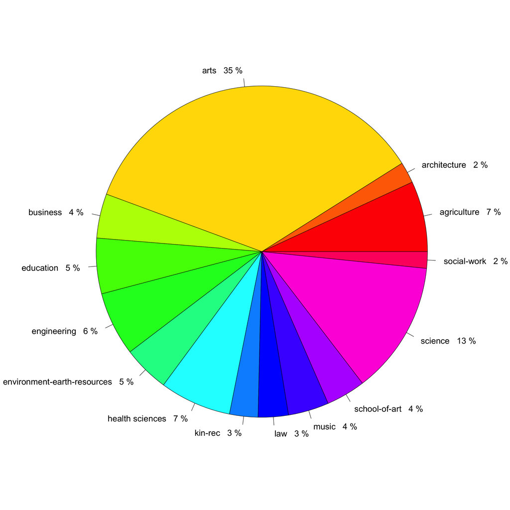

## Which department shares the most classes with another

Each department’s course code corresponds to exactly one specific course (e.g., MATH 1500 refers to **Introduction to Calculus**, and LAW 1500 refers to **Property**). Given this relationship, a natural question arises: which departments have the most overlap in their course codes?

```r
library(dplyr)


createOverlapCodeMatrix <- function(df) {
  # BIOE appears twice in both agriculture and bio engineering and since faculty doesn't matter, remove engineering for simplicty
  df <- df %>%
    filter(!(dept == "BIOE" & faculty == "engineering"))
  # Only departments with ten or more classes are considered
  largeDeptVec <- names(which(table(df$dept) > 10))
  # symmetric matrix where each i,j entry is a pair of departments
  mostCommonMatrix <- matrix(nrow = length(largeDeptVec), ncol = length(largeDeptVec), dimnames = list(largeDeptVec, largeDeptVec))
  # iterate through each possible pair
  for (y in 1:length(largeDeptVec)) {
    for (x in 1:length(largeDeptVec)) {
      # name for department 1 and 2
      target1 <- colnames(mostCommonMatrix)[[x]]
      target2 <- colnames(mostCommonMatrix)[[y]]
      # combine the two department codes
      combinedVec <- df %>%
        filter(dept == target1 | dept == target2) %>%
        pull(code)
      temp <- table(combinedVec)
      # The table will only return either 1 (no overlap) or 2 (only occurs if both courses use same code)
      mostCommonMatrix[y,x] <- sum(temp == 2)

    }
  }
  mostCommonMatrix
}
commonMatTest = createOverlapCodeMatrix(all_courses)
diag(commonMatTest) = rep(0, ncol(commonMatTest))

which(commonMatTest == max(commonMatTest), arr.ind=TRUE)
```

```
##      row col
## RLGN  71  42
## HIST  42  71
```

```r
max(commonMatTest)
```

```
## [1] 26
```

The most two departments with the most course codes in common among the two are **History** and **Religion** with 26 codes shared among the two. Note these are pure counts and not accounting for lopsided department sizes

### Ranking other department pairs

Pairs of departments that share the **most**/**least** common course codes

These may include courses *no longer availiable*

[output not shown]

## Analyzing digits

As mentioned earlier, the course codes are not assigned arbitrarily—there are noticeable patterns in their usage. For example, even-numbered codes appear to be favored over odd-numbered ones. Let’s now visualize this trend using barplots and pie charts

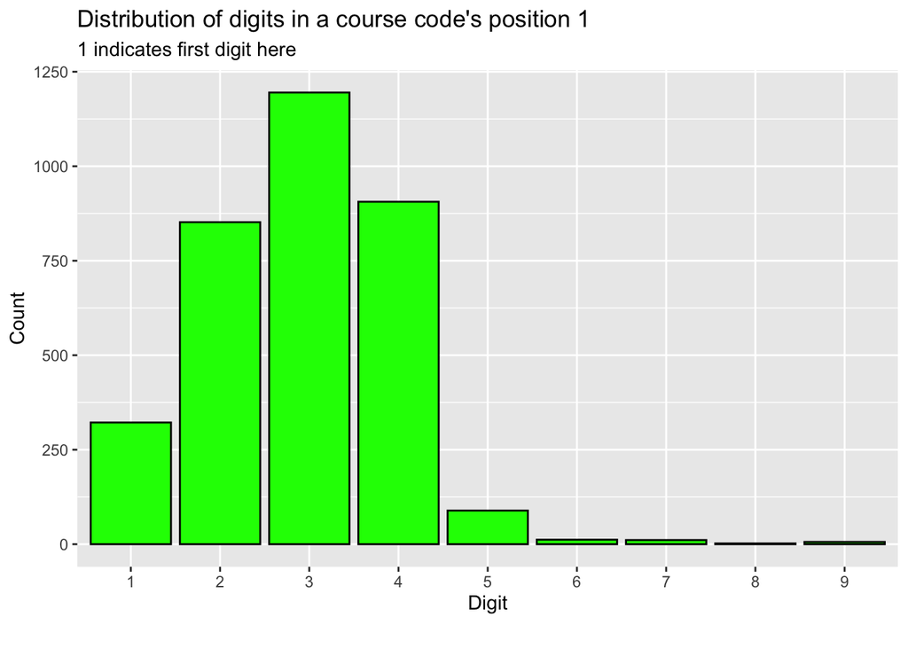

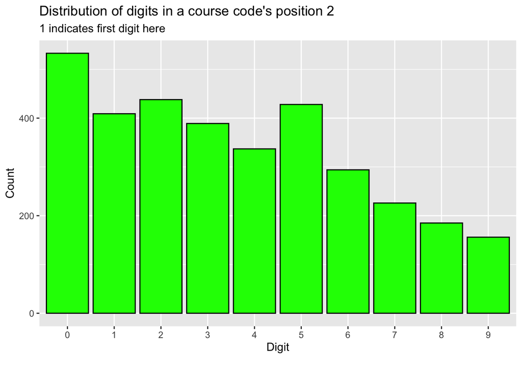

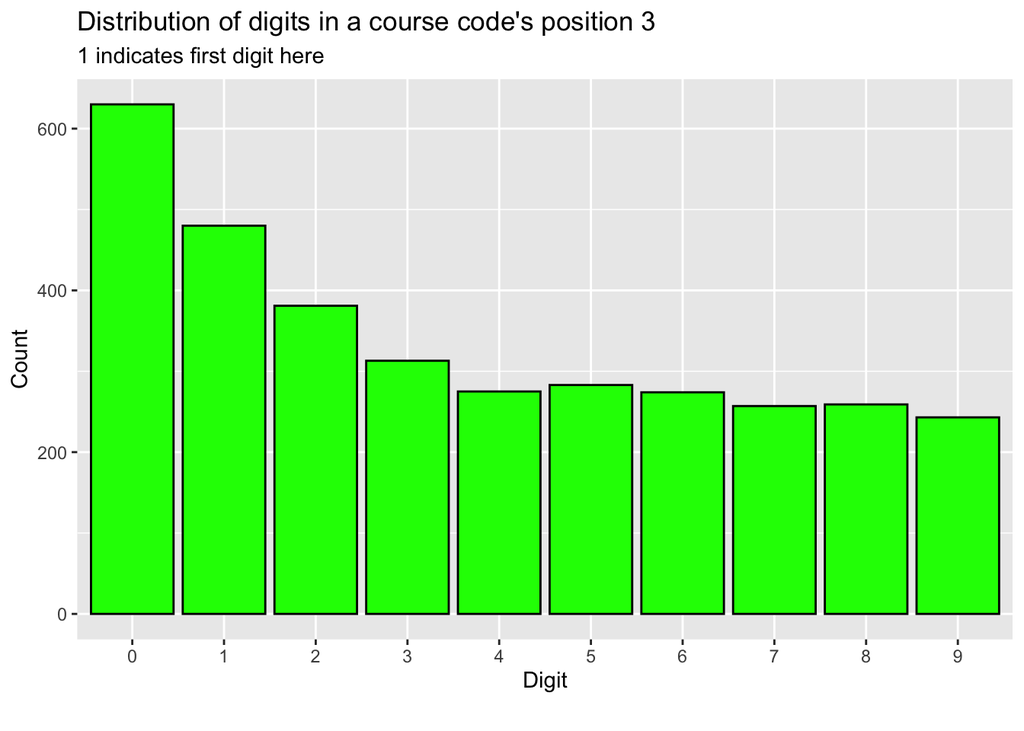

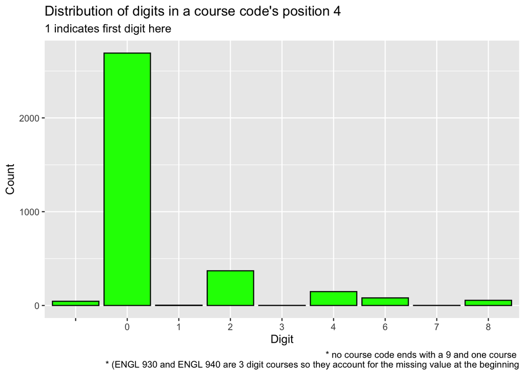

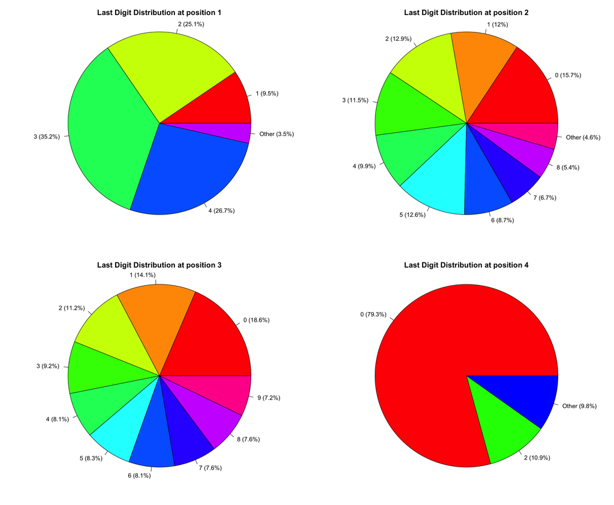

## Conclusion for digits used

### Trailing digit

It is somewhat surprising how heavily the digit 0 is favored as the final digit in course codes. However, this preference aligns with our natural tendency to favor round numbers. Codes ending in 0 are easier to categorize, remember, and organize mathematically, as we are accustomed within a base-10 system. This pattern is clearly reflected in the accompanying pie chart, which shows a disproportionately high use of codes ending in 0 compared to other digits.

### Middle digit(s)

When examining the second and third digits, there is less consistency across departments, but a few informal patterns emerge. It appears common practice to increment course codes by 10 to indicate a continuation or second part of a course (e.g., 2210 following 2200), and by 100 to signal a shift to a different but related topic or level (e.g., 2200 to 2300). This structured numbering helps both administrators and students recognize relationships between courses at a glance, even if the system isn’t rigidly enforced university-wide.

An excellent example of structured course code usage can be found in the Computer Science department. COMP 1010 (Introduction to Computer Science 1) and COMP 1020 (Introduction to Computer Science 2) are directly related and designed as sequential prerequisites, with the increment of 10 clearly signaling a continuation. Meanwhile, COMP 1500 and COMP 1600 focus on different topics, and the differing second digits likely serve to distinguish between subject areas within the same level. Additionally, COMP 1012 (Computer Programming for Scientists and Engineers) covers similar introductory content but is tailored to engineering students and is not a direct prerequisite for COMP 1020.

That said, this pattern is not applied consistently—even within the same department. As courses progress into the second and third years, the use of the second and third digits becomes less predictable, suggesting that while course codes may reflect structure in some cases, exceptions are common and likely driven by administrative or historical factors.

It is worth noting that the mindset between determining course codes could change overtime which might be true in this case as the courses mentioned were offered overtime

### Leading digit

The distribution of course levels reveals that third-year courses are the most commonly offered. As shown in the chart, this makes sense within the academic progression: first-year courses focus on fundemtal material with little room for specialization; second-year courses begin to branch out but still emphasize core topics. By the third year, students are academically prepared to choose from a wider range of specialized courses, increasing the volume of offerings at that level. In contrast, fourth-year courses are often more niche, with stricter prerequisites, which naturally limits their availability and enrollment.

# Analyzing word usage in course titles

# Course titles Analysis

## What is the shortest and longest course name

|  | course | name | faculty | word_count |
| --- | --- | --- | --- | --- |
| 960 | GPE 1700 | Social Justice in the 21st Century: Global Political Economy and Environmental Change | arts | 12 |
| 2083 | GEOG 1700 | Social Justice in the 21st Century: Global Political Economy and Environmental Change | environment-earth-resources | 12 |
| 630 | ECON 2550 | Political Economy 2: Economic Growth and Fluctuations in a Global Economic Environment | arts | 12 |
| 1026 | HIST 3290 | The United States from World War II to the War on Terror (A) | arts | 13 |
| 888 | GRMN 4210 | Survey of Second Language Acquisition and Methods of Language Teaching in German (B) | arts | 13 |
| 881 | GRMN 3282 | Sex, Gender and Cultural Politics in the German-Speaking World in English Translation (C) | arts | 13 |
| 3055 | SWRK 4286 | Mino Shkaabis with First Nations, Metis, Inuit Children, Youth and Families: Critical Analysis | social-work | 13 |
| 1683 | EDUB 3426 | La pédagogie du français de base aux niveaux intermédiare et de la jeune enfance | education | 14 |
| 967 | HIST 1260 | New Directions in History: Inquiries into the Cultural Basis of the Modern World (G) | arts | 14 |
| 968 | HIST 1270 | New Directions in History: Inquiries into the Power Relations of the Modern World (G) | arts | 14 |

[output cut: 5 more lines]

**Note:** The list is sorted by word count first, then by character count, and finally alphabetically.

## Summary by faculty

| faculty | mean_words | shortest_name | longest_name |
| --- | --- | --- | --- |
| social-work | 7.1 | Field Instruction 1 | Mino Pimatisiwin in Northern Rural and Isolated Communities Focusing on Treaties 5 and 10 |
| education | 5.5 | School Band | La pédagogie du français de base aux niveaux intermédiare et de la jeune enfance |
| arts | 4.3 | Kant | New Directions in History: Inquiries into the Cultural Basis of the Modern World (G) |
| architecture | 4.2 | Field Studies | History of Culture, Ideas and Environment 1 |
| health sciences | 4.2 | Medicine | Introduction to the Evaluation of Programs for Children and Families |
| environment-earth-resources | 4.1 | Gemology | Social Justice in the 21st Century: Global Political Economy and Environmental Change |
| agriculture | 4.0 | Genetics | Agricultural and Food Sciences Co-operative Education Work Term 1 |
| kin-rec | 4.0 | Biomechanics | Parks and Protected Areas Planning and Management: Field Studies |
| engineering | 3.7 | Thesis | Design of RF Devices and Wireless Systems |
| music | 3.7 | Ensemble | From Rock to Rap and Beyond: A History of Popular Music in the Later 20th Century |

[output cut: 4 more lines]

It’s worth noting that Social Work stands out as an outlier relative to other faculties. The average course title in this faculty is around seven words, significantly longer than most others. This is likely because of the nature of the field—Social Work courses often focus around specific groups, needs, or situations, like community work, mental health, or culturally sensitive care. As a result, course names tend to be more descriptive to accurately convey the target demographic or specialized focus. To illustrate, five courses starts with *Social Work Practice* and then the following words are targeted for a specific demographic.

| code | courseName |
| --- | --- |
| SWRK 1200 | Introduction to Canadian Social Welfare |
| SWRK 1210 | Wâhkôhtowin: We are All Related |
| SWRK 1220 | Social Justice, Diversity and Human Rights |
| SWRK 1230 | Community Health and Well-Being: Imagination for Social Work Practice |
| SWRK 1240 | Social Work and Professional Identity |
| SWRK 1250 | Human Behaviour, Family and Community Well-Being: Theory and Practice |
| SWRK 2000 | Anti-racist Social Work Practice |
| SWRK 2010 | Indigenization and Decolonization in Social Work |
| SWRK 2020 | Community Development and Social Work |
| SWRK 2030 | Communication and Relational Skills in Social Work |

[output cut: 45 more lines]

Conversely, **Business** and **Law** have the shortest average course title lengths, both averaging around 3.4 words per course. This conciseness likely reflects the well-established and standardized nature of these disciplines, where much of the terminology is already familiar to students and professionals alike. As a result, course titles tend to be direct and unambiguous—often needing no further elaboration to convey their purpose. Their straightforward naming style mirrors the clarity and precision expected in these fields.

## Summary grouped by department

| dept | mean_words | shortest_name | longest_name |
| --- | --- | --- | --- |
| SWRK | 7.1 | Field Instruction 1 | Mino Pimatisiwin in Northern Rural and Isolated Communities Focusing on Treaties 5 and 10 |
| GRMN | 6.7 | German Romanticism (B) | My Friend the Tree: Environment and Ecology in German Culture in English Translation (C) |
| HIST | 6.7 | Selected Topics | New Directions in History: Inquiries into the Cultural Basis of the Modern World (G) |
| GPE | 6.5 | Studies in Global Political Economy | Social Justice in the 21st Century: Global Political Economy and Environmental Change |
| EDUB | 5.9 | School Band | La pédagogie du français de base aux niveaux intermédiare et de la jeune enfance |
| DATA | 5.7 | Data Science Capstone Project | Data Science with Real World Data Sets |
| NURS | 5.6 | Clinical Practicum | Professional Foundations 3: Evidence Informed Practice in the Health Sciences |
| CLAS | 5.4 | Pompeii and Herculaneum | Roman History: The Roman Empire, 30 BC-AD 337 |
| CATH | 5.3 | Catholicism on Film | Mystics, Saints, and Sinners: The Quest for Holiness in the Catholic Church |
| AGRI | 5.2 | Business Communication | Agricultural and Food Sciences Co-operative Education Work Term 1 |

[output cut: 105 more lines]

# Do year levels use more or less words?

To examine whether the number of words in a course title differs based on year level, a one-way ANOVA was conducted. If the ANOVA results are significant, it would suggest that year level has an effect on title length. However, it is important to note that while a significant ANOVA result indicates that **at least** one group mean is different from the others, it does not specify which group differ.

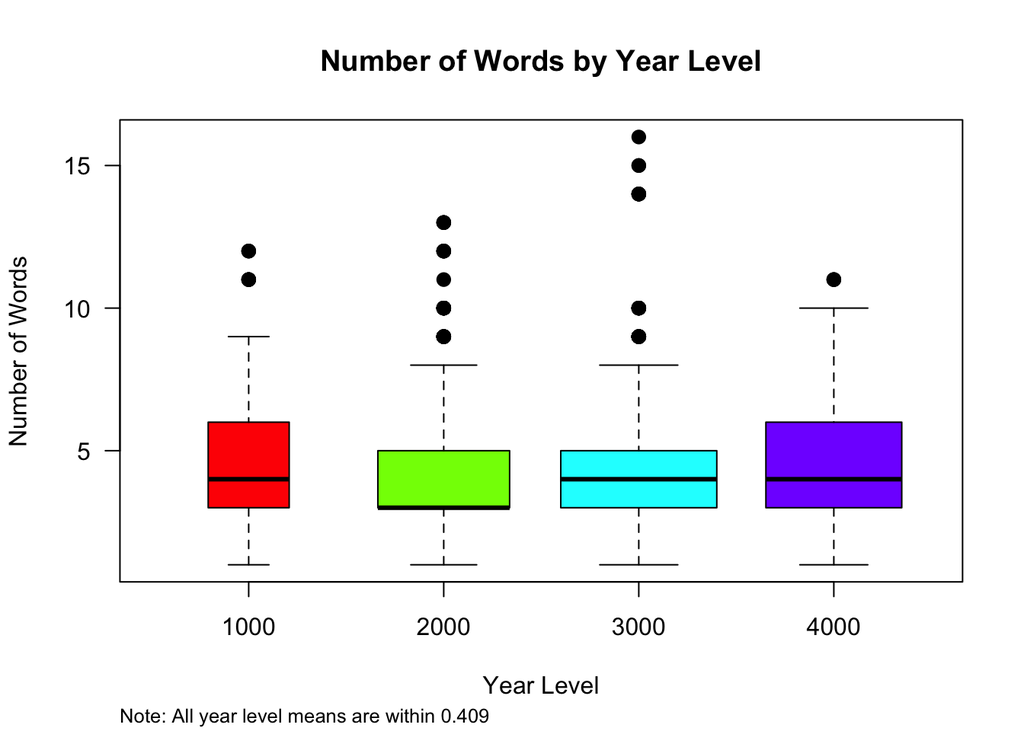

```
##                   Df Sum Sq Mean Sq F value   Pr(>F)
## factor(yearLvl)    3     66  22.017   5.774 0.000619 ***
## Residuals       3271  12473   3.813
## ---
## Signif. codes:  0 '***' 0.001 '**' 0.01 '*' 0.05 '.' 0.1 ' ' 1
```

Interpreting the differences in mean title lengths can be somewhat difficult, but one possible explanation is: First-year course titles tend to be slightly longer, which suggests a need to provide more detail for students who are new to the subject area. In contrast, second and third-year courses are usually become more specialized, allowing for more concise titles that assume a basic familiarity with the field. By fourth year, title lengths increase again—possibly because these courses build on third-year content and require more specific wording to differentiate the advanced or extended nature of the topics.

## What are the most frequent words

```
## words
##          and           in           of          the           to            1
##          855          613          410          294          256          235
##            2 introduction       topics     advanced      history      studies
##          211          209          189          133          132          110
##   management          for       social
##          102           99           96
```

## Which department uses the most common words

A word is considered **unique** if it only appears in one department, and **common** if it’s used by more than one. This helps us see which departments stand out more based on how many unique words they use. There are *1522** unique words and *797* common words

## Which department uses the most common words

The method used to determine this was by calculating the proportion of unique words relative to the total number of words used by each department. While it’s not practical to display every unique word for each department, I will highlight the most interesting or representative ones

| dept | unique_words | total_words | unique_porportion |
| --- | --- | --- | --- |
| FREN | 62 | 90 | 0.68888889 |
| ASTR | 17 | 28 | 0.60714286 |
| EER | 2 | 4 | 0.50000000 |
| DDSS | 11 | 24 | 0.45833333 |
| RSTD | 10 | 22 | 0.45454545 |
| GEOL | 37 | 86 | 0.43023256 |
| MUSC | 62 | 152 | 0.40789474 |
| LAW | 63 | 167 | 0.37724551 |
| SWRK | 59 | 157 | 0.37579618 |
| MECH | 39 | 105 | 0.37142857 |

[output cut: 105 more lines]

### Language department

Language departments, only 3 departments (ICEL (icelandic), SPAN (Spanish) and POL (Polish) mention the country in one of their courses) In fact Icelandic also includes swedish in their name for a course. ICEL 1300

### Courses with years

Only a few course titles actually include a specific year range, like “1871–1921,” which usually signals a tight focus on a particular historical period. This kind of naming mostly shows up in History courses. Interestingly, INDG (Indigenous Studies) is the only other department that uses this format, likely to highlight key historical moments in its subject matter. Other departments do cover history too—for example, ASIA often splits things into “before 1500” and “after 1500”—but they don’t usually include exact years in the course titles

| course_code | course_name | faculty |
| --- | --- | --- |
| INDG 2520 | Indigenous Experience in the U.S. 1860-Present | arts |
| HIST 1370 | Modern World History: 1500-1800 (M) | arts |
| HIST 1380 | Modern World History: 1800-Present (M) | arts |
| HIST 1390 | History of Colonial Canada: 1500-1885 (C) | arts |
| HIST 2220 | The Shaping of Modern Ireland, 1500-Present (E) | arts |
| HIST 2350 | Europe 1789-1870 (E) | arts |
| HIST 2390 | Early Modern Europe, 1450-1789 (E) | arts |
| HIST 2654 | History of the People's Republic of China, 1949-Present (B) | arts |
| HIST 2730 | Modern World History, 1914-1945: The 30 Years' Crisis (M) | arts |
| HIST 2732 | Modern World History, 1945-1992: The Age of Three Worlds (M) | arts |

[output cut: 4 more lines]

```
##  [1] "arabic"
##  [2] "17e, africain, analyses, antilles, au, beauvoir, bilingues, bureau, canadienfrançais, canadiennefrançaise, canadiensfrançais, cinéma, civilisation, contemporain, contreculture, critiques, dafrique, dans, des, dixhuitième, dixneuvième, écrite, enjeux, études, féminine, française, francophone…
##  [3] "agents, beginnings, brothers, classicism, countries, enlightenment, fairy, friend, germanspeaking, grimm, hollywood, my, representations, secret, spies, surveillance, tales, treason, tree"
##  [4] "folktales, iceland, icelanders, icelandic, icelandiccanadian, legends, norse, sagas, swedish, viking"
##  [5] "get, graphic, lets, novels, speaking, voyage"
##  [6] "aeneid, augustan, cicero, comedy, eclogues, elegiac, georgics, lyric, orations, republican, satire, silver, vergils"
##  [7] "acoustic, algonquian, asl, descriptive, endangerment, gesture, hearing, interpretation, linguistics, multilingualism, neuroanatomy, phonological, phonology, pragmatics, semantics, sociolinguistic, sociolinguistics, speech, syntactic, verbal, words"
##  [8] "heroes, patriotism, poland, polish"
##  [9] "chekhov, dostoevsky, stalin, tolstoy, tolstoys"
## [10] "gogol"
## [11] "accelerated, bunuel, dali, female, golden, lorca, native, playwrights, pronunciation, spanish, testimony, vocabulary, voices"
## [12] "holodomor, rites, rituals, shevchenko"
## [13] "yiddish"
```

## Which course uses the most common words

The course that was recreated first is considered the one that relies most heavily on common words.

The table below shows, for each department, the number of iterations (i.e., how many of the most common words were needed) to fully reconstruct one course title, along with the course itself. A value of “-1” under “words_needed” indicates that no course in the department could be fully reconstructed, meaning all titles contained at least one unique word.

| dept | recomposed | words_needed | reconstructed_course |
| --- | --- | --- | --- |
| UCHS | TRUE | 762 | the ukrainian arts in canada |
| SLAV | TRUE | 749 | special topics in comparative german and slavic studies |
| ICEL | TRUE | 749 | special topics |
| MSCI | TRUE | 747 | introduction to management sciences |
| SCI | TRUE | 743 | thinking critically about science |
| ACC | TRUE | 719 | canadian income taxation |
| EVAR | TRUE | 704 | architecture design studio 1 |
| UKRN | TRUE | 703 | special studies |
| CDN | TRUE | 703 | seminar in canadian studies |
| OPM | TRUE | 672 | simulation models for operations management |

[output cut: 105 more lines]

| dept | recomposed | words_needed | reconstructed_course |
| --- | --- | --- | --- |
| IDM | TRUE | 786 | sustainable business |
| BTEC | TRUE | 786 | work term 1 |
| UCHS | TRUE | 762 | the ukrainian arts in canada |
| MIS | TRUE | 749 | database management systems |
| BGEN | TRUE | 747 | medical cell biology |
| MSCI | TRUE | 747 | introduction to management sciences |
| GPE | TRUE | 729 | studies in global political economy |
| OPM | TRUE | 672 | simulation models for operations management |
| REHB | TRUE | 633 | research methodology for medical rehabilitation |
| AGEC | TRUE | 579 | principles of ecology |

[output cut: 3 more lines]

## Measuring Simularity between departments by word usage

To compare the similarity between departments—an idea related to [document distance](https://medium.com/@tusharsadana/document-distance-7094a4cb732b)—I treated each department’s collection of course titles as a single “document.” By pooling all course titles for a given department, I created a word-frequency vector for each one. Each vector entry corresponds to a word, with its value representing how frequently that word appears in the department’s course titles.

To measure similarity between departments, I used the normalized dot product of their word-frequency vectors. This method captures the degree of overlap in word usage: values closer to 1 indicate high similarity, while values near 0 suggest little to no shared terminology. Though the dot product is not formally a document distance metric (such as cosine distance), it serves a similar purpose here while being computationally simpler. The normalization ensures that comparisons remain apples to apples even when departments have vastly different numbers of courses.

This approach offers a straightforward way to quantify how closely departments are related based on the language in their course titles. It can highlight overlapping subject areas or draw out distinct disciplinary boundaries.

One limitation is that it does not capture the semantic similarity of different words. For instance, departments focused on “women” and “gender” may be topically aligned, but if they use different vocabularies, the dot product will fail to reflect that relationship.

### How the results are stored

This approach uses a **similarity matrix** where each row and column represents a department. Each entry in the matrix is the normalized dot product between the word-frequency vectors of two departments. Higher values (closer to 1) indicate stronger similarity in course title vocabulary, while lower values (closer to 0) suggest less overlap. The goal is to identify the pairs of departments with the highest similarity scores.

To ensure meaningful comparisons, only departments with at least **15 courses** are included in the analysis. This threshold helps avoid noise from small departments that may not be well-represented.

We compute similarity using two methods:

- **Raw word frequency**: The vectors are built from raw word counts across each department’s course titles.
- **Weighted frequency [(TF-IDF-style)](https://www.capitalone.com/tech/machine-learning/understanding-tf-idf/)**: Here, word frequencies are adjusted to account for how common each word is across all departments. This down-weights common words like “and” (which may appear in many departments) and gives more weight to rarer, more informative terms like “Greek”, which may appear in only a few.

A corollary is that this results in a **symmetric matrix**—the similarity between department A and department B is the same as between B and A. The output will list the most similar department pairs as `(row, column)` pairs; since the order doesn’t matter, `(A, B)` and `(B, A)` are considered equivalent.

Most similar departments (unweighted)

| RowDept | ColDept | distance |
| --- | --- | --- |
| BIOE | CIVL | 0.689 |
| BIOE | MECH | 0.663 |
| CIVL | MECH | 0.661 |
| RLGN | WOMN | 0.641 |
| FMLY | SOC | 0.617 |
| CLAS | RLGN | 0.616 |
| KPER | REC | 0.612 |
| FOOD | HNSC | 0.611 |
| KIN | KPER | 0.611 |
| ECE | MECH | 0.602 |
| FMLY | RLGN | 0.596 |
| CIVL | ECE | 0.589 |
| RLGN | SOC | 0.586 |
| SOC | SWRK | 0.578 |
| EVIE | EVLU | 0.563 |

Lease similar departments (unweighted)

| RowDept | ColDept | distance |
| --- | --- | --- |
| FREN | HNSC | 0.000 |
| FREN | MDFY | 0.000 |
| FREN | SOC | 0.001 |
| FIN | FREN | 0.004 |
| CIVL | FREN | 0.005 |
| FREN | SCM | 0.005 |
| ENTM | FREN | 0.008 |
| FREN | PLNT | 0.014 |
| FREN | REC | 0.016 |
| ANSC | FREN | 0.017 |
| PLNT | RSTD | 0.017 |
| FREN | SWRK | 0.019 |
| BIOE | FREN | 0.020 |
| EVLU | FREN | 0.020 |
| FREN | GEOL | 0.022 |

Most similar departments (TF-IDF)

| RowDept | ColDept | distance |
| --- | --- | --- |
| CLAS | GRK | 0.5066587 |
| FOOD | HNSC | 0.4287169 |
| BIOE | CIVL | 0.4137320 |
| CIVL | MECH | 0.3767086 |
| ABIZ | AGRI | 0.3628662 |
| CIVL | ENG | 0.3617948 |
| BIOE | ENG | 0.3600304 |
| BIOE | MECH | 0.3423231 |
| ABIZ | ECON | 0.3395463 |
| ECE | ENG | 0.3213256 |
| CIVL | ECE | 0.3188909 |
| KPER | REC | 0.2964947 |
| AGRI | FOOD | 0.2907255 |
| BIOE | ECE | 0.2839480 |
| ENG | MECH | 0.2811494 |

Least similar departments (TF-IDF)

| RowDept | ColDept | distance |
| --- | --- | --- |
| FREN | HNSC | 0.00e+00 |
| FREN | MDFY | 0.00e+00 |
| PLNT | RSTD | 1.40e-06 |
| MDFY | RSTD | 4.10e-06 |
| HNSC | RSTD | 5.40e-06 |
| FREN | SOC | 6.40e-06 |
| DDSS | ENTM | 9.10e-06 |
| DDSS | SCM | 1.20e-05 |
| DDSS | FIN | 1.28e-05 |
| ENTM | MDFY | 1.33e-05 |
| MDFY | THTR | 1.48e-05 |
| MDFY | SCM | 1.53e-05 |
| LABR | RSTD | 2.07e-05 |
| FIN | FREN | 2.64e-05 |
| ANTH | DDSS | 2.92e-05 |

### Which departments are least similar to others

To identify which departments stand out as the most linguistically distinct, we compute the average similarity of each department to all others using the normalized dot product similarity matrix. This approach focuses purely on how closely a department’s course titles align with those from other departments. Departments with the lowest average similarity scores tend to use more specialized or unique terminology, potentially hinting a larger disconnect between the other departments.

```
##        RSTD        DDSS        ENTM         SCM        UKRN        ICEL
## 0.002527684 0.004945464 0.005350426 0.006896702 0.008493969 0.009320497
##        SPAN        RUSN         FIN        FREN         ACT        GEOL
## 0.009545961 0.010646251 0.011177147 0.012025866 0.012072274 0.012232838
##        THTR        PHYS        MUSC        ASIA        FILM        LING
## 0.012384661 0.013069190 0.013593496 0.013625208 0.014260079 0.014553821
##        GEOG        LATN        ANTH         GRK        PHMD        GRMN
## 0.014870630 0.015181866 0.015964503 0.016158508 0.016313817 0.016429436
##        LABR        PHIL        CHEM        STAT        MDFY        MBIO
## 0.016543042 0.016881432 0.017244958 0.017682420 0.017716963 0.018140250
##        FAAH        POLS        WOMN        EVIE        NURS        RESP
## 0.018484224 0.018547915 0.018749564 0.018851054 0.019134381 0.019239017
##        EDUA        RLGN        MATH        PLNT         LAW        INDG
## 0.019633099 0.019715700 0.020006183 0.020049507 0.020229661 0.021308782
##         KIN         REC        ANSC        PSYC        EDUB        STDO
## 0.021776584 0.021918594 0.022201523 0.022636578 0.022897560 0.023549620
##        CLAS        COMP        HNSC        FOOD         SOC        EVLU
## 0.023668615 0.023915256 0.023963542 0.024619588 0.025186312 0.025811826
##        FMLY        HIST        KPER        ECON        ENGL        BIOL
## 0.025983716 0.026084333 0.026504368 0.026875395 0.026954808 0.029813330
##        ABIZ         SCI         ECE        ENVR        MECH        AGRI
## 0.031144005 0.033159705 0.034364084 0.035279903 0.035515864 0.036987319
##        EVDS        SWRK        CIVL        BIOE         ENG
## 0.038644211 0.038725309 0.040215773 0.042341527 0.047293072
```

One issue that this method has is that it does not account for the fact that each department is associated with a faculty. Recall that the school-of-art has only two departments whereas science has seventeen which potentially give science departments an unfair advantage.

### Do departments share more similarity between the same faculty vs outside faculty

One solution to account for the discrepancy is that we compute the mean document distance within and between the faculties. Higher within-faculty similarity would suggest that departments under the same faculty tend to use more common terminology. Conversely, lower similarity across faculties would highlight distinct disciplinary boundaries. This comparison helps reveal how organizational structure at the faculty level influences the language and themes expressed in course offerings

The results will be categorized based on **faculty relationship** and **frequency measurement**. Specifically, they will be grouped as **within-faculty** (courses from the same faculty) and **between-faculty** (courses from different faculties). Each of these categories will be further subdivided by frequency type: **unweighted** (raw counts) and **weighted** (TF-IDF scores, as defined earlier).

The resulting categories are:

- `unweighted_within`
- `unweighted_between`
- `unweighted_diff`
- `weighted_within`
- `weighted_between`
- `weighted_diff`

| faculty | unweighted_within | unweighted_between | unweighted_diff | TF_IDF_within | TF_IDF_between | TF_IDF_diff |
| --- | --- | --- | --- | --- | --- | --- |
| agriculture | 0.7457631 | 0.8128125 | 0.067049397 | 0.9284455 | 0.9818885 | 0.05344296 |
| business | 0.7692468 | 0.8608539 | 0.091607081 | 0.9473468 | 0.9872181 | 0.03987125 |
| health sciences | 0.8567312 | 0.8664185 | 0.009687276 | 0.9566924 | 0.9887111 | 0.03201865 |
| arts | 0.7843406 | 0.8336923 | 0.049351763 | 0.9740945 | 0.9905603 | 0.01646587 |
| science | 0.7733900 | 0.8293349 | 0.055944835 | 0.9413709 | 0.9831075 | 0.04173655 |
| engineering | 0.4332911 | 0.7917579 | 0.358466862 | 0.6492332 | 0.9765796 | 0.32734636 |
| education | 0.4545813 | 0.7383478 | 0.283766484 | 0.8521917 | 0.9803404 | 0.12814875 |
| environment-earth-resources | 0.7957719 | 0.8040943 | 0.008322440 | 0.9577164 | 0.9824761 | 0.02475966 |
| architecture | 0.5282620 | 0.8227574 | 0.294495448 | 0.8212886 | 0.9832199 | 0.16193126 |
| school-of-art | 0.7101064 | 0.8400419 | 0.129935463 | 0.8896951 | 0.9841576 | 0.09446253 |

[output cut: 1 more lines]

# Conducting a hypothesis test to confirm.

One observation you may have noticed is that the engineering department is noticably more similar in within then between (0.3). However how can we be certain this was not due to chance?

A [permutation test](https://www.jwilber.me/permutationtest/) is a way to determine whether an observed difference between two groups is likely to have happened by chance. It works by randomly shuffling the group labels (in our case “within-faculty” and “between-faculty”) many times, while keeping the actual data the same. After each shuffle, the difference between the groups is recalculated and stored. This creates a distribution of differences that would be expected if we **assumed** there were no real distinction between the groups. The original, observed difference is then compared to this distribution. If the observed difference is much larger (or smaller) than most of the shuffled results (by convention 0.05), it suggests that the difference is unlikely to be due to random chance and is therefore statistically meaningful.

Before conducting the permutation test, a few considerations need to be addressed: * The **weighted** document distance will be used only * Faculties with only one department will be excluded, as there are no internal comparisons possible in such cases. * To ensure more balanced comparisons—particularly within larger faculties such as Arts, Business, and Science—we will pre-sample departments to be included in the test. * The test will be run using multiple random seeds to incorporate variability and avoid results that depend on a single random sampling. * It’s possible that a pre-sample may be unintentionally skewed toward a specific category (for example, selecting only language-related departments within Arts). However, this does not pose a problem for our analysis, as the permutation test is designed to handle such variability.

```
##                 agriculture                    business
##            "fail to reject"            "fail to reject"
##             health sciences                     science
##            "fail to reject"            "fail to reject"
##                 engineering                   education
##            "fail to reject"            "fail to reject"
## environment-earth-resources                architecture
##            "fail to reject"            "fail to reject"
##               school-of-art                        arts
##            "fail to reject"            "fail to reject"
##                     kin-rec                         law
##            "fail to reject"                        "-1"
##                       music                 social-work
##                        "-1"                        "-1"
```

### What went wrong?

- **Permutation test may not be sensitive to differences** The test may suffer from **reduced statistical power** due to adjustments for uneven faculty sizes, making it **more conservative** when rejecting the null hypothesis—potentially too conservative. Moreover, the test could be **misleading when swapping similar departments across different faculties** during permutations. Such swaps might falsely assume that the two faculties are similar, even when they are not, which can distort the results and undermine the test’s validity.
- **Flaws of the In/Out Faculty Framework and Its Relation to the Curse of Higher Dimensionality:** Categorizing document comparisons simply as “within faculty” versus “between faculty” assumes a clear-cut distinction in language use. However, this leads to a high dimensional and sparsity of document vectors, this assumption becomes problematic. The [**curse of higher dimensionality**](https://en.wikipedia.org/wiki/Curse_of_dimensionality) makes it difficult to detect true similarities and differences because distances tend to concentrate and noise (unexpected causes that potentially interfere with our test) increases.

### Solutions

While it is possible to conduct pairwise comparisons between faculties, doing so would significantly reduce statistical power because the test would need to be simultaneously correct for each faculty pair, increasing the chance of false positives. Moreover, merging faculties to increase sample size is not wise, as it would discard critical, faculty-specific information essential for meaningful analysis.

Additionally, using permutation testing may be problematic when relying on the dot product as a similarity measure. For instance, swapping labels between faculties such as Engineering and Science can produce misleading results since words like “Engineering” carry a high information, causing dot product values to remain non-zero and defeating the randomization process.

- Could do each pair at once but that would signficantly reduce power. And that we can’t merge faculties together since it intentionally discards too much critical infomation
- Permutation might not be right since we are using dot product, ie swapping engineering with science would make the dot product entry non zero and engineering is a very infomation dense word

## Is there a corelation between number of unique words and doc distance

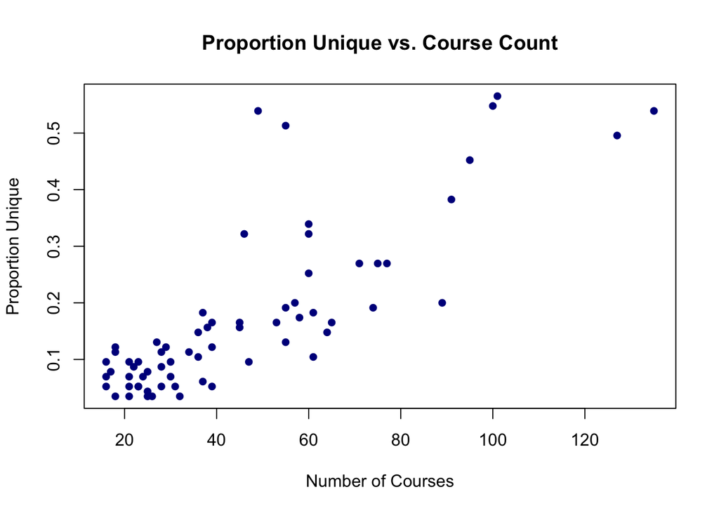

[figure not shown]

## Which word is the most information dense

Some words, such as *“and”* or *“(1)”*, are extremely common across all course titles and provide little to no information about a specific department—they don’t help narrow things down. On the other hand, some words are rare but highly specific to a department (e.g., *“statistics”* may appear mostly in STAT and PHYS), but identifying these high-value words often requires a degree of luck or prior knowledge.

A way to quantify how valuable a word is could be taken from the famous game **Wordle**. This has been done in 3Blue1Brown’s video where **information theory** was used. Similar to Wordle, a random department will be selected and entering a word in any of the departments course titles will narrow down which department is used.

To approach this more systematically, we can apply **information theory**, taking inspiration in 3Blue1Brown’s video regarding WORDLE. The goal is to determine how informative a given word is in narrowing down the possible departments. Specifically, we want to find the **expected number of departments remaining** after observing a particular word—this can be modeled using a series of **Bernoulli trials**.

This approach allows us to move beyond intuition or chance, using a principled, data-driven method to find the most informative terms for narrowing down academic departments based on course titles.

## View this in action

In this simulation, a random seed is used to generate the game sequence. During each round, the algorithm calculates the top five words based on information gain, and the word with the highest score is selected as the guess. When only a single department remains, the correct department is known with certainty.

```
## A department has been chosen. Try to guess it by entering words!
##
## Possible departments left: 115
##
##  Suggested next words:
##       word info_gain
## 1      the 0.9999455
## 2        2 0.9955774
## 3   topics 0.9933900
## 4        1 0.9709506
## 5 advanced 0.9709506
## The word 'the' is in the target department.
##
## Possible departments left: 58
##
##  Suggested next words:
##       word info_gain
## 1  studies 1.0000000
## 2 advanced 0.9965664
## 3  special 0.9922666
## 4  culture 0.9688977
## 5      for 0.9688977
## The word 'studies' is in the target department.
##
## Possible departments left: 29
##
##  Suggested next words:
##         word info_gain
## 1    history 0.9991421
## 2 literature 0.9991421
## 3    special 0.9991421
## 4    seminar 0.9991421
## 5    culture 0.9922666
## The word 'history' is NOT in the target department.
##
## Possible departments left: 15
## CATH, EDUA, ENVR, FMLY, GEOG, GEOL, GPE, HEAL, ITLN, LING, POLS, REC, RUSN, SPAN, UKRN
##
##  Suggested next words:
##          word info_gain
```

[output cut: 32 more lines]

```
## RUSN, SPAN
##
##  Suggested next words:
##           word info_gain
## 1      russian         1
## 2 masterpieces         1
## 3         love         1
## 4      english         1
## 5        until         1
## The word 'russian' is NOT in the target department.
##
## Possible departments left: 1
## SPAN
##
##  Correct! The department was: SPAN You took 7 guesses
```

## All the words entropy for stage 1

| word | info_gain | deptContains | deptWithout |
| --- | --- | --- | --- |
| the | 0.99994546 | 58 | 57 |
| 2 | 0.99557740 | 62 | 53 |
| topics | 0.99339005 | 63 | 52 |
| 1 | 0.97095059 | 69 | 46 |
| advanced | 0.97095059 | 46 | 69 |
| introduction | 0.96563613 | 70 | 45 |
| of | 0.95362932 | 72 | 43 |
| to | 0.93211157 | 75 | 40 |
| management | 0.92398416 | 39 | 76 |
| for | 0.92398416 | 39 | 76 |

[output cut: 2239 more lines]